# DNA methylation and enrichment analysis

Louis Meller

```r
suppressPackageStartupMessages({
  library(epiwraps)
  library(ggplot2)
  library(AnnotationHub)
  library(ensembldb)
  library(edgeR)
  library(rtracklayer)
  library(BiocParallel)
  library(bsseq) # Class and tools to analyze bisulfite sequencing data at CpG-level
  library(DMRcate) # Identification of differentially-methylated regions
})
```

## Load the data

```r
download.file("https://ethz-ins.org/content/w11_practical.zip", "w11_practical.zip")
unzip("w11_practical.zip")
```

## Assignment 1: Plot a heatmap of the methylation levels of the genes in top 5 DMR regions (from the practical) located on chr1. You may either do this as we did for promoters during the practical (i.e. using `getMeth()`), or using `signal2Matrix()` and `plotEnrichedHeatmaps()`.

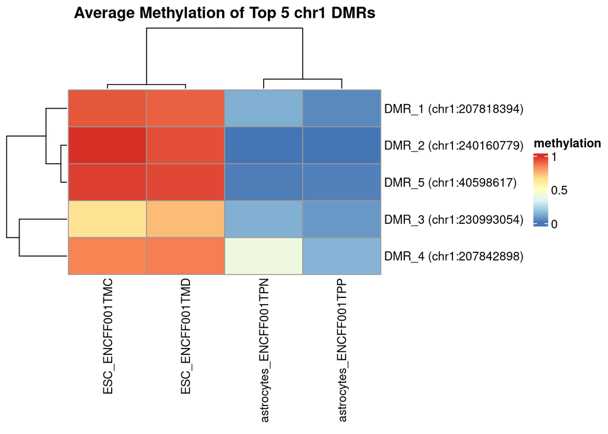

```r
dmrs <- readRDS("dmr.rds")
bs <- readRDS("ESC_astrocytes_BSseq.rds")

bs <- bs[rowSums(assay(bs, "Cov") > 0) == ncol(bs), ]
bs <- BSmooth(bs, BPPARAM = BiocParallel::MulticoreParam(4))

dmrs_chr1 <- dmrs[seqnames(dmrs) == "chr1"]
top5_dmrs_chr1 <- head(dmrs_chr1[order(abs(dmrs_chr1$meandiff), decreasing = TRUE)], 5)

names(top5_dmrs_chr1) <- paste0("DMR_", 1:5, " (", seqnames(top5_dmrs_chr1), ":", start(top5_dmrs_chr1), ")")

meth_top5 <- bsseq::getMeth(bs, regions = top5_dmrs_chr1, what = "perRegion")
rownames(meth_top5) <- names(top5_dmrs_chr1)

pheatmap(meth_top5,
  main = "Average Methylation of Top 5 chr1 DMRs",
  name = "methylation"
)
```

Here we visualized the raw methylation levels across the samples for the five most significant dmrs on chr1. We can see that ESC and astrocyte replicates cluster within groups. This shows that methylation profiles are very distinct across these cell types. Further, methylation decreases from ESC to astrocyte, which is expected during differentiation.

## Assignment 2: Use the differentially-methylated regions from the practical, and compare those changes to changes in accessibility. Given these two datasets, figure out a way (visualization/analysis) of assessing the extent of agreement (or disagreement) between changes in these two modalities.

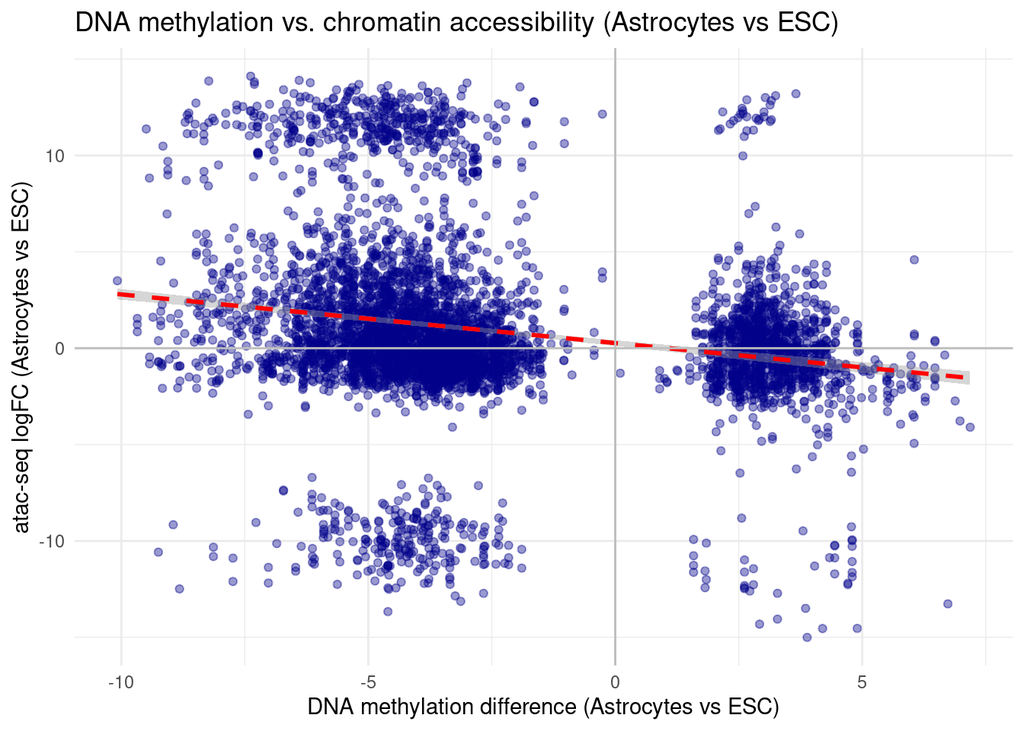

```r
download.file("https://www.ethz-ins.org/content/ATAC_AstroVsESC_subset.rds", "ATAC_AstroVsESC_subset.rds")
atac <- readRDS("ATAC_AstroVsESC_subset.rds")

overlaps <- findOverlaps(dmrs, atac)

comparison_df <- data.frame(
  meth_diff = dmrs$meandiff[queryHits(overlaps)],
  atac_logFC = atac$logFC[subjectHits(overlaps)]
)

ggplot(comparison_df, aes(x = meth_diff, y = atac_logFC)) +
  geom_point(alpha = 0.4, color = "darkblue") +
  geom_smooth(method = "lm", color = "red", linetype = "dashed") +
  theme_minimal() +
  labs(
    title = "DNA methylation vs. chromatin accessibility (Astrocytes vs ESC)",
    x = "DNA methylation difference (Astrocytes vs ESC)",
    y = "atac-seq logFC (Astrocytes vs ESC)"
  ) +
  geom_hline(yintercept = 0, color = "grey") +
  geom_vline(xintercept = 0, color = "grey")
```

Here we plotted atac-seq log fc against DNA methylation mean diff for regions where dmrs and atac peaks were measured in both ESC and astrocyte cells. The negative correlation shows that regions gaining DNA methylation lose chromatin accesibility, which is expected.